# Tugas Individu Minggu 7

# Ukuran Kelayakan Model

```r
summary_model <- summary(model)

(r_squared <- summary_model$r.squared)
```

```
## [1] 0.8855804
```

```r
(adj_r_squared <- summary_model$adj.r.squared)
```

```
## [1] 0.8767789
```

# Penanganan Masalah

Uji asumsi-asumsi yang telah dilakukan sebelumnya menunjukkan perlunya transformasi agar terbentuk model yang lebih baik, salah satunya karena terbentuknya pola parabola pada plot residual.

## Transformasi untuk Meluruskan: Pola Parabola

Transformasi ini dilakukan dengan Y diperkecil, yaitu $Y^* = \sqrt{Y}$.

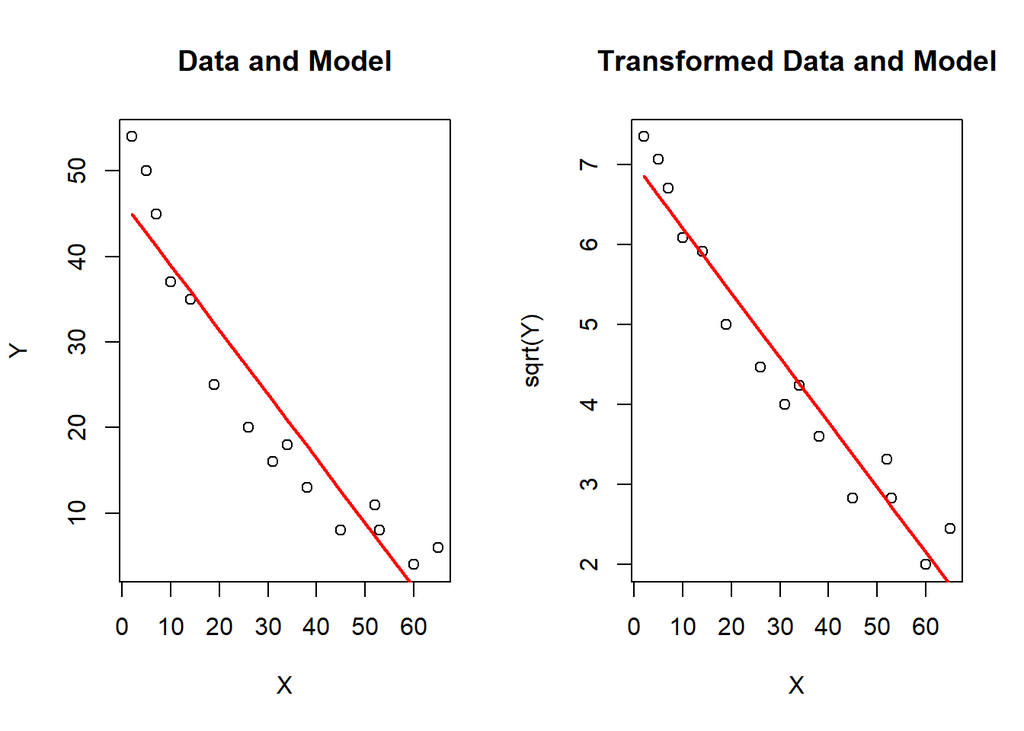

```r
data_transformed <- data.frame(X, sqrt(data$Y))
model2 <- lm(sqrt(Y) ~ X, data=data_transformed)

predicted_values <- predict(model, data)
predicted_values2 <- predict(model2, data_transformed)

par(mfrow = c(1, 2))
plot(X,Y,main="Data and Model", xlab="X", ylab="Y")
lines(X, predicted_values, col="red", lwd=2)

plot(X, sqrt(data$Y), main="Transformed Data and Model", xlab="X", ylab="sqrt(Y)")
lines(X, predicted_values2, col="red", lwd=2)
```

```r
par(mfrow = c(1, 1))
```

# Uji Asumsi Setelah Transformasi

## Nilai harapan galat sama dengan nol

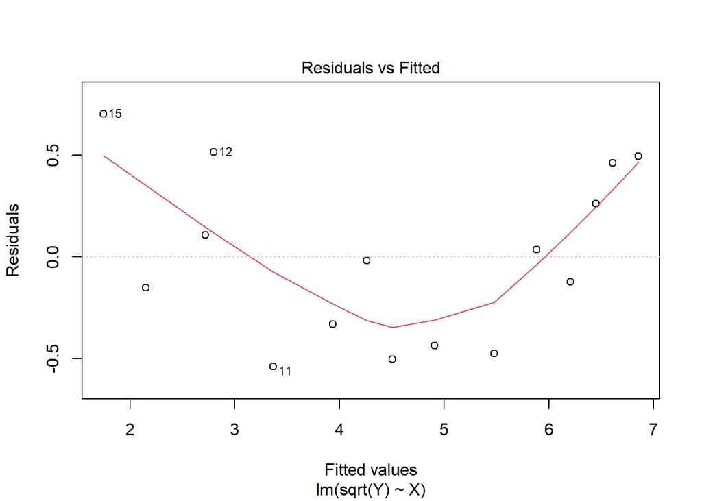

```r
plot(model2, 1)
```

Uji Formal
$$H_0: E[\epsilon] = 0
\text{(nilai harapan galat sama dengan nol)}$$
$$H_1: E[\epsilon] \neq 0 \text{(nilai harapan
galat tidak sama dengan nol)}$$

```r
library(coin)
t.test(model2$residuals,mu=0,conf.level=0.95)
```

```
##
##  One Sample t-test
##
## data:  model2$residuals
## t = -1.0367e-16, df = 14, p-value = 1
## alternative hypothesis: true mean is not equal to 0
## 95 percent confidence interval:
##  -0.229541  0.229541
## sample estimates:
##   mean of x
## -1.1095e-17
```

Hasil uji t-test menunjukkan bahwa p-value > 0.05 sehingga tidak tolak H0. Hal ini mengindikasikan nilai harapan galat sama dengan 0.

## Ragam galat homogen atau homoskedastisitas ($\text{var}[\epsilon] = \sigma^2 I$)

$$H_0: \text{var}[\epsilon] = \sigma^2
I$$
$$H_1: \text{var}[\epsilon] \neq
\sigma^2 I$$

```r
library(lmtest)
bptest(model2, data=data)
```

```
##
##  studentized Breusch-Pagan test
##
## data:  model2
## BP = 0.93605, df = 1, p-value = 0.3333
```

Hasil uji bptest menunjukkan bahwa p-value > 0.05 sehingga tidak tolak H0. Hal ini mengindikasikan ragam galat homogen.

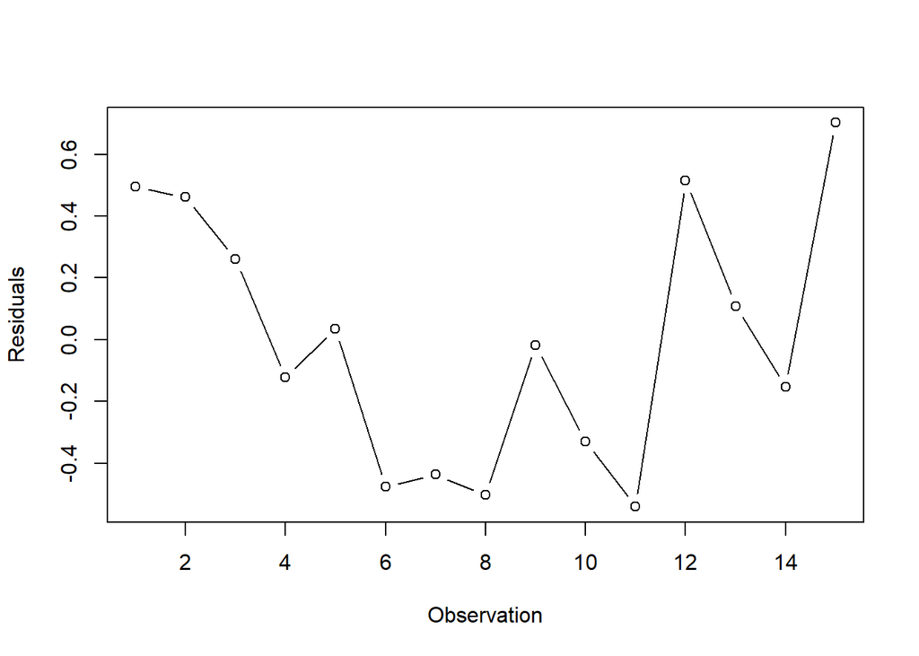

```r
plot(x = 1:dim(data)[1],
     y = model2$residuals,
     type = 'b',
     ylab = "Residuals",
     xlab = "Observation")
```

## Galat saling bebas

Uji Formal
$$H_0: E[\epsilon_i,
\epsilon_j] = 0$$
$$H_1: E[\epsilon_i,
\epsilon_j] \neq 0$$

```r
library(randtests)
runs.test(model2$residuals)
```

```
##
##  Runs Test
##
## data:  model2$residuals
## statistic = -0.55635, runs = 7, n1 = 7, n2 = 7, n = 14, p-value = 0.578
## alternative hypothesis: nonrandomness
```

Hasil runs test menunjukkan bahwa p-value > 0.05 sehingga tidak tolak $H_0$. Hal ini mengindikasikan bahwa tidak ada autokorelasi atau sisaan saling bebas.

## Galat Menyebar Normal

Uji Formal
$$H_0 = N$$
$$H_1 \neq N$$

```r
shapiro.test(residuals(model2))
```

```
##
##  Shapiro-Wilk normality test
##
## data:  residuals(model2)
## W = 0.93128, p-value = 0.2852
```

Berdasarkan uji *shapiro-test* didapatkan bahwa p-value > 0.05 sehingga tidak tolak $H_0$. Artinya, galat menyebar normal.

# Ukuran Kelayakan Model 2

```r
summary_model2 <- summary(model2)

(r_squared2 <- summary_model2$r.squared)
```

```
## [1] 0.9439477
```

```r
(adj_r_squared2 <- summary_model2$adj.r.squared)
```

```
## [1] 0.939636
```

#Perbandingan Ukuran Kelayakan Model

```r
(table_data <- data.frame(
  Model = c("Model 1", "Model 2"),
  R_squared = c(r_squared, r_squared2),
  Adj_R_squared = c(adj_r_squared, adj_r_squared2)
))
```

```
##     Model R_squared Adj_R_squared
## 1 Model 1 0.8855804     0.8767789
## 2 Model 2 0.9439477     0.9396360
```

Dapat terlihat bahwa baik $R^2$ maupun $R^2_\text{adj}$ memiliki nilai yang lebih besar dan lebih mendekati nilai 1 pada model 2 hasil transformasi daripada model pratransformasi sehingga dapat dikatakan bahwa model 2 lebih layak dibandingkan model 1.

# Pendugaan Parameter Regresi

```r
summary(model2)
```

```
##
## Call:
## lm(formula = sqrt(Y) ~ X, data = data_transformed)
##
## Residuals:
##      Min       1Q   Median       3Q      Max
## -0.53998 -0.38316 -0.01727  0.36045  0.70199
##
## Coefficients:
##              Estimate Std. Error t value Pr(>|t|)
## (Intercept)  7.015455   0.201677   34.79 3.24e-14 ***
## X           -0.081045   0.005477  -14.80 1.63e-09 ***
## ---
## Signif. codes:  0 '***' 0.001 '**' 0.01 '*' 0.05 '.' 0.1 ' ' 1
##
## Residual standard error: 0.4301 on 13 degrees of freedom
## Multiple R-squared:  0.9439, Adjusted R-squared:  0.9396
## F-statistic: 218.9 on 1 and 13 DF,  p-value: 1.634e-09
```

Dugaan persamaan regresi hasil transformasi sebagai berikut.
$$\sqrt {Y^*} = 7.015 - 0.081X$$

# Tranformasi Balik

$$\sqrt {Y^*} = 7.015 - 0.081X$$
$$Y^* = (7.015 - 0.081X)^2$$
$$Y^* = 49.210 - 1.136X + 0.00656X^2$$